# Report - PCA for PhenotyperPCA Project

Kate Konrad

2026-11-27

# Results

Here, we present the results of for the analysis of the data. This output includes:

- A heatmap of the data values
- Parameter significance plots
- The percent of variation explained by notable PCs
- ANOVA tests for notable PCs
- Tukey pairwise comparison testing for notable PCs
- PC loading plots colored by Variable Type and Covariate Signifiance
- Boxplots of notable PC scores

This analysis is an example used for the template

This dataset has litter effects

Variables that are used in the analysis include Sex and Treatment (with possible values of 0 mg/kg, 0.5 mg/kg, 5 mg/kg) and their interactions.

If specified in the input, this file will also apply multiple testing comparisons (MTC) to the ANOVAs (for the main variables and for the Principal Components Analysis). Comparisons will be applied within the model covariates (that is, Sex and Treatment, and their interaction) and across the variables. The procedure used here is: BH.

## Data

This dataset was called ../Data for Practice/15_join01and13L_prenatalCPF.xlsx. First, we looked at a heatmap of the data, followed by removing variables that are highly correlated. This dataset has litter effects

### Excluded variables

There were 25 variables that were intentionally removed from analysis. These were:

```
##  [1] "Mean activity duration - dark (s)"
##  [2] "Mean short arrest duration - dark (s)"
##  [3] "Mean long arrest duration - dark (s)"
##  [4] "Mean short shelter visit duration - dark (s)"
##  [5] "Mean long movement distance - dark (cm)"
##  [6] "Mean short movement distance - dark (cm)"
##  [7] "Mean activity duration - habituation ratio dark (ratio)"
##  [8] "Mean short arrest duration - habituation ratio dark (ratio)"
##  [9] "Mean long arrest duration - habituation ratio dark (ratio)"
## [10] "Mean short shelter visit duration - habituation ratio dark (ratio)"
## [11] "Mean long movement distance - habituation ratio dark (ratio)"
## [12] "Mean short movement distance - habituation ratio dark (ratio)"
## [13] "Mean long shelter visit duration (s)"
## [14] "Mean activity duration - light (s)"
## [15] "Mean short arrest duration - light (s)"
## [16] "Mean long arrest duration - light (s)"
## [17] "Mean short shelter visit duration - light (s)"
## [18] "Mean long movement distance - light (cm)"
## [19] "Mean short movement distance - light (cm)"
## [20] "Mean activity duration - darklight index (index)"
## [21] "Mean short arrest duration - darklight index (index)"
## [22] "Mean long arrest duration - darklight index (index)"
## [23] "Mean short shelter visit duration - darklight index (index)"
## [24] "Mean long movement distance - darklight index (index)"
## [25] "Mean short movement distance - darklight index (index)"
```

There were 2 variables that have a missing value and must be removed from the PCA. These were:

```
## [1] "Long shelter visit duration - habituation ratio dark (ratio)"
## [2] "Spout zone duration - habituation ratio dark (ratio)"
```

At correlation cutoff value 0.99, the following variables were removed from the PCA:

```
## [1] "No variables were removed; all were below the correlation cutoff value."
```

### Heatmaps

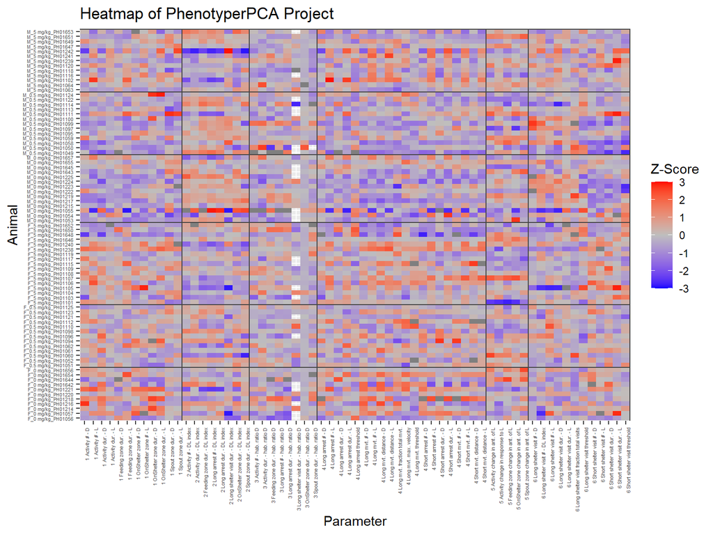

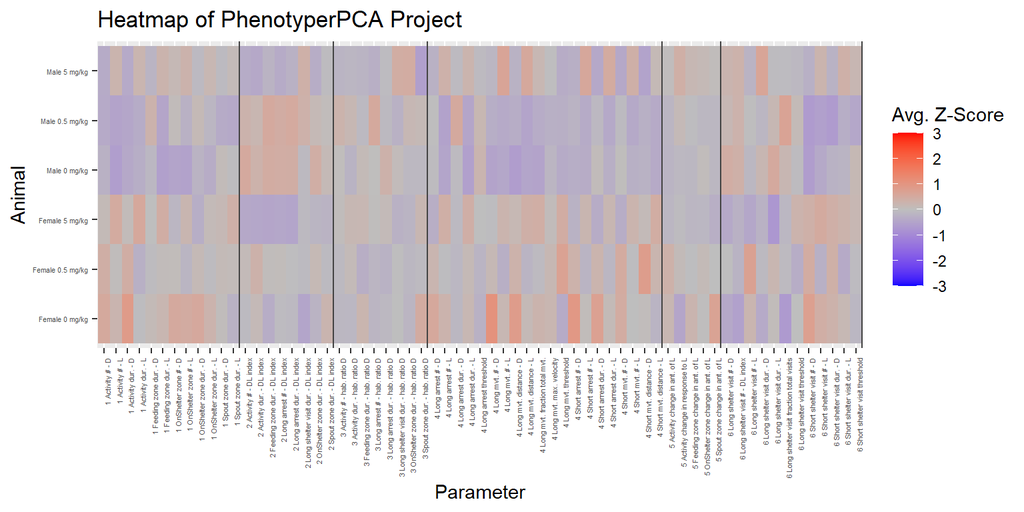

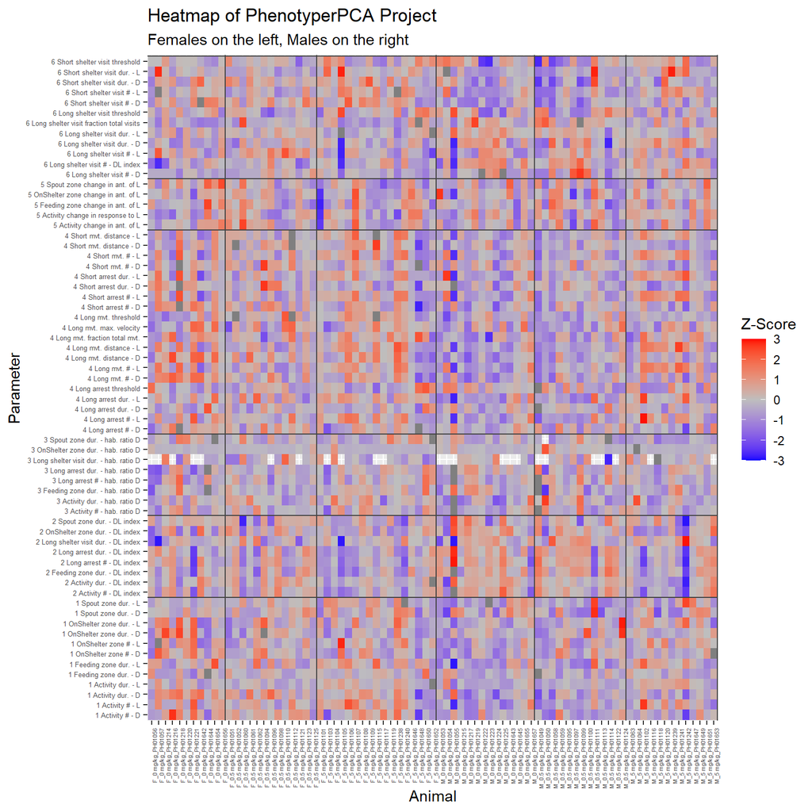

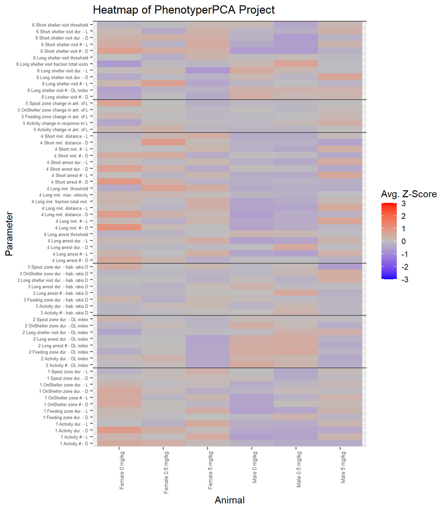

### Clustered Heatmap

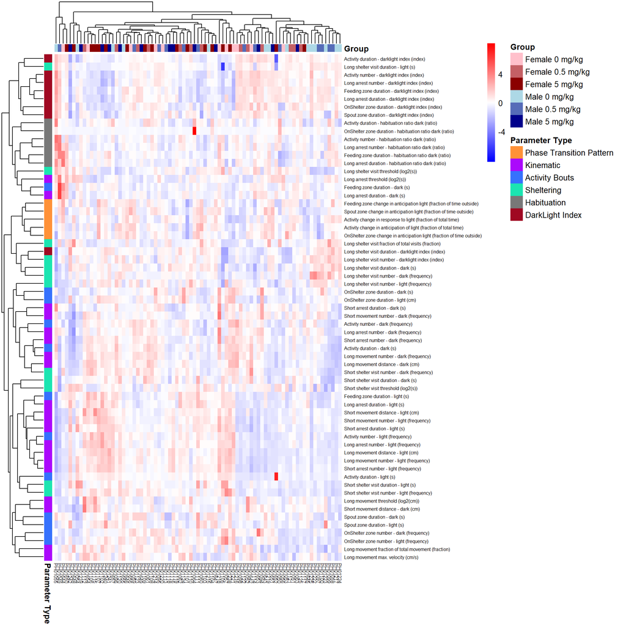

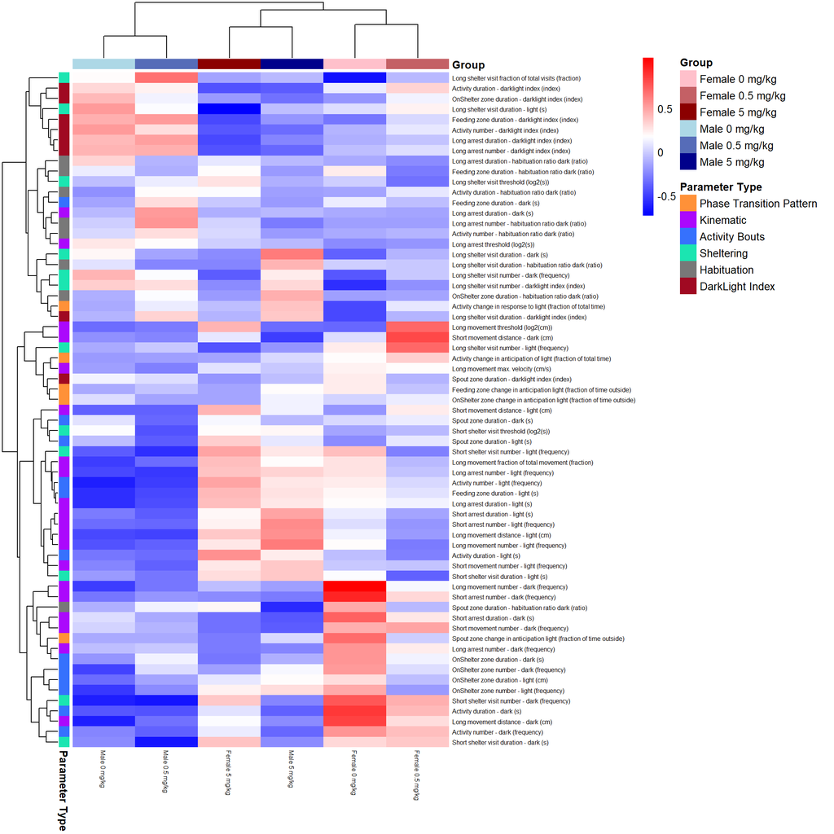

## ANOVA of main variables

A colored box indicates that the variable was significant at the 0.05 level.

ANOVA models done with a random effect for litter.

The model results shown below are from a nested model - first interaction models are performed, and if the interaction is not significant, then additive models are performed.If Interaction p-value is significant (alpha < 0.05), then the main effect p-values are from that interaction model. If the Interaction p-value is not significant, the the main effect p-values are from an additive model.

### Graphical Results

The nested model structure can be visualized below. A significant interaction term from an interaction model is in its parameter type color (green, purple, etc.). The other terms in the interaction model (sex and Treatment) are grey if not significant and colorful if significant. A non-significant interaction model is replaced with an additive model. Additive models have a white interaction as a placeholder (there is no interaction in the additive model). Otherwise, the main terms are grey if not significant and colorful if significant.

If multiple testing corrections were applied, then covariates that are still significant after the correction are marked with an asterisk (*). In this case, the muplitle testing correction used was the BH method.

Colorful - significant term Grey - non-significant term in the model White - term not in model (additive)

The two plots below show the same model output, but the first is filtered for those variables that had a significant Treatment term or a significant interaction term. The second plot shows all variables.

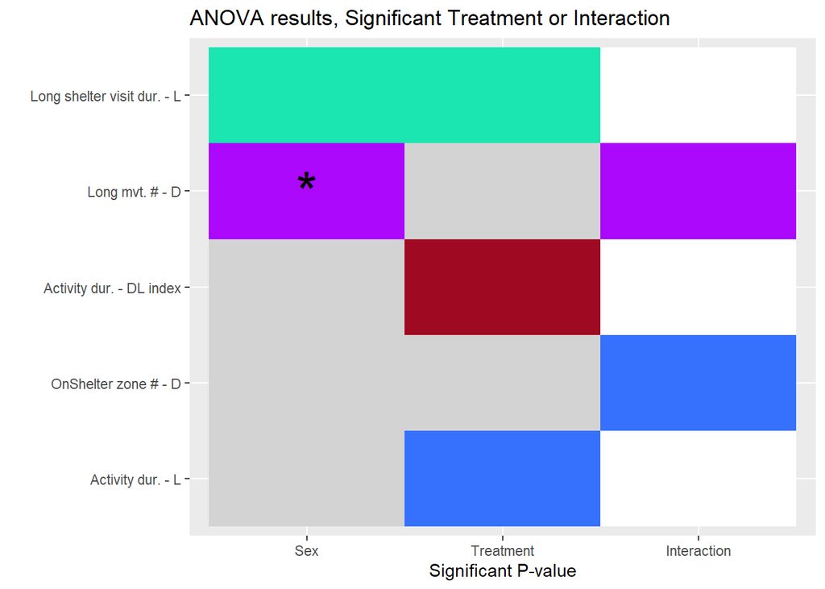

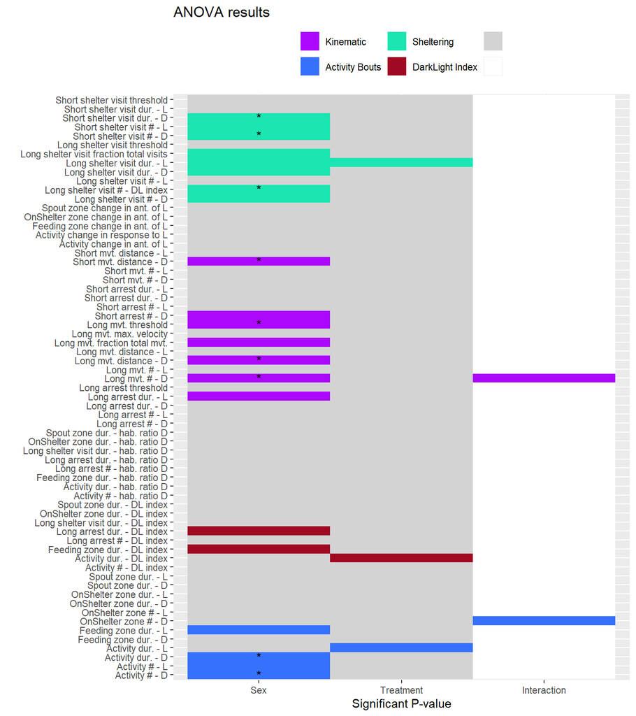

### Tabular Results

ANOVA results

[output not shown]

* Multiple Testing Corrections were applied to each covariate across the variables. Interaction p-values were grouped across the interaction models. Main effect p-values were groups across the final model, whether interaction or additive (see footnote below). The BH procedure was used here.  
Bolded cells indicate a p-value less than 0.05.  
ANOVA models done with a random effect for litter. Nested model: If Interaction p-value is significant (alpha < 0.05), then the main effect p-values are from that interaction model. If the Interaction p-value is not significant, then the main effect p-values are from an additive model.

## Principal Components Analysis

Significant PCs, based off of an ANOVA.

ANOVA models done with a random effect for litter.

PCs with a significant ANOVA covariate (nested model)

| PC | % Variation Explained | ANOVA p-values and MTC p-values* Sex | ANOVA p-values and MTC p-values* Sex, BH | ANOVA p-values and MTC p-values* Treatment | ANOVA p-values and MTC p-values* Treatment, BH | ANOVA p-values and MTC p-values* Sex x Treatment | ANOVA p-values and MTC p-values* Sex x Treatment , BH |
| --- | --- | --- | --- | --- | --- | --- | --- |
| PC1 | 26.1% | 0.02 | 0.23 | 0.16 | 0.92 | NA | 0.64 |
| PC2 | 15.3% | <0.01 | 0.12 | 0.16 | 0.92 | NA | 0.83 |
| PC7 | 3.8% | 0.29 | 0.81 | 0.32 | 0.92 | 0.04 | 0.64 |
| PC13 | 1.7% | 0.02 | 0.23 | 0.62 | 0.92 | NA | 0.87 |
| PC17 | 1.1% | 0.50 | 0.94 | 0.71 | 0.92 | <0.01 | 0.12 |
| PC20 | 0.8% | 0.02 | 0.23 | 0.06 | 0.92 | NA | 0.83 |
| PC27 | 0.4% | 0.03 | 0.26 | 0.53 | 0.92 | NA | 0.87 |
| PC31 | 0.2% | 0.02 | 0.23 | 0.44 | 0.92 | NA | 0.74 |
| PC33 | 0.2% | 0.58 | 0.94 | 0.05 | 0.92 | NA | 0.83 |

Shaded rows indicate that the % of variation explained by the PC is greater than 1.5%, and their score and loading plots will be shown below.  
* Multiple Testing Corrections were applied to each covariate across the variables. Interaction p-values were grouped across the interaction models. Main effect p-values were groups across the final model, whether interaction or additive (see footnote below). The BH procedure was used here.  
Bolded cells indicate a p-value less than 0.05.  
ANOVA models done with a random effect for litter. Nested model: If Interaction p-value is significant (alpha < 0.05), then the main effect p-values are from that interaction model. If the Interaction p-value is not significant, the the main effect p-values are from an additive model.

If the PC explains less than 1.5% of the variability, its Loadings and Scores are not plotted in the Significant PC Plots tab.

For completeness, all PCs are shown below.

PCs with a significant ANOVA covariate (nested model)

| PC | % Variation Explained | ANOVA p-values and MTC p-values* Sex | ANOVA p-values and MTC p-values* Sex, BH | ANOVA p-values and MTC p-values* Treatment | ANOVA p-values and MTC p-values* Treatment, BH | ANOVA p-values and MTC p-values* Sex x Treatment | ANOVA p-values and MTC p-values* Sex x Treatment , BH | Cumulative % of Variation explained |  |
| --- | --- | --- | --- | --- | --- | --- | --- | --- | --- |
| PC1 | 26.1% | 0.02 | 0.23 | 0.16 | 0.92 | NA | 0.64 |  | 26.1% |
| PC2 | 15.3% | <0.01 | 0.12 | 0.16 | 0.92 | NA | 0.83 | 41.4% |  |
| PC3 | 8.7% | 0.63 | 0.94 | 0.46 | 0.92 | NA | 0.64 | 50.1% |  |
| PC4 | 6.1% | 0.19 | 0.78 | 0.50 | 0.92 | NA | 0.99 | 56.1% |  |
| PC5 | 5.4% | 0.22 | 0.80 | 0.88 | 0.94 | NA | 0.87 | 61.5% |  |
| PC6 | 4.7% | 0.86 | 0.96 | 0.43 | 0.92 | NA | 0.64 | 66.3% |  |
| PC7 | 3.8% | 0.29 | 0.81 | 0.32 | 0.92 | 0.04 | 0.64 | 70.1% |  |
| PC8 | 3.4% | 0.76 | 0.94 | 0.96 | 0.96 | NA | 0.99 | 73.5% |  |
| PC9 | 2.8% | 0.89 | 0.96 | 0.56 | 0.92 | NA | 0.64 | 76.2% |  |
| PC10 | 2.6% | 0.88 | 0.96 | 0.46 | 0.92 | NA | 0.99 | 78.9% |  |
| PC11 | 2.3% | 0.90 | 0.96 | 0.80 | 0.92 | NA | 0.83 | 81.2% |  |
| PC12 | 2.2% | 0.26 | 0.81 | 0.80 | 0.92 | NA | 0.87 | 83.3% |  |
| PC13 | 1.7% | 0.02 | 0.23 | 0.62 | 0.92 | NA | 0.87 | 85.1% |  |
| PC14 | 1.7% | 0.54 | 0.94 | 0.29 | 0.92 | NA | 0.64 | 86.7% |  |
| PC15 | 1.4% | 0.08 | 0.39 | 0.65 | 0.92 | NA | 0.64 | 88.2% |  |
| PC16 | 1.2% | 0.34 | 0.81 | 0.61 | 0.92 | NA | 0.87 | 89.4% |  |
| PC17 | 1.1% | 0.50 | 0.94 | 0.71 | 0.92 | <0.01 | 0.12 | 90.5% |  |
| PC18 | 1.0% | 0.62 | 0.94 | 0.58 | 0.92 | NA | 0.99 | 91.5% |  |
| PC19 | 0.9% | 0.37 | 0.85 | 0.90 | 0.94 | NA | 0.95 | 92.3% |  |
| PC20 | 0.8% | 0.02 | 0.23 | 0.06 | 0.92 | NA | 0.83 | 93.2% |  |
| PC21 | 0.8% | 0.94 | 0.96 | 0.13 | 0.92 | NA | 0.99 | 94.0% |  |
| PC22 | 0.6% | 0.67 | 0.94 | 0.46 | 0.92 | NA | 0.95 | 94.6% |  |
| PC23 | 0.6% | 0.87 | 0.96 | 0.95 | 0.96 | NA | 0.99 | 95.2% |  |
| PC24 | 0.5% | 0.31 | 0.81 | 0.77 | 0.92 | NA | 0.64 | 95.7% |  |
| PC25 | 0.5% | 0.05 | 0.37 | 0.35 | 0.92 | NA | 0.64 | 96.2% |  |
| PC26 | 0.4% | 0.93 | 0.96 | 0.18 | 0.92 | NA | 0.87 | 96.6% |  |
| PC27 | 0.4% | 0.03 | 0.26 | 0.53 | 0.92 | NA | 0.87 | 97.0% |  |
| PC28 | 0.3% | 0.92 | 0.96 | 0.13 | 0.92 | NA | 0.87 | 97.3% |  |
| PC29 | 0.3% | 0.44 | 0.88 | 0.54 | 0.92 | NA | 0.87 | 97.6% |  |
| PC30 | 0.3% | 0.62 | 0.94 | 0.73 | 0.92 | NA | 0.64 | 97.9% |  |
| PC31 | 0.2% | 0.02 | 0.23 | 0.44 | 0.92 | NA | 0.74 | 98.1% |  |
| PC32 | 0.2% | 0.66 | 0.94 | 0.76 | 0.92 | NA | 0.87 | 98.3% |  |
| PC33 | 0.2% | 0.58 | 0.94 | 0.05 | 0.92 | NA | 0.83 | 98.5% |  |
| PC34 | 0.2% | 0.08 | 0.39 | 0.47 | 0.92 | NA | 0.64 | 98.7% |  |
| PC35 | 0.2% | 0.52 | 0.94 | 0.21 | 0.92 | NA | 0.64 | 98.9% |  |
| PC36 | 0.2% | 0.18 | 0.78 | 0.50 | 0.92 | NA | 0.64 | 99.1% |  |
| PC37 | 0.1% | 0.07 | 0.39 | 0.85 | 0.94 | NA | 0.64 | 99.2% |  |
| PC38 | 0.1% | 0.43 | 0.88 | 0.20 | 0.92 | NA | 0.87 | 99.3% |  |
| PC39 | 0.1% | 0.75 | 0.94 | 0.54 | 0.92 | NA | 0.64 | 99.4% |  |
| PC40 | 0.1% | 0.69 | 0.94 | 0.24 | 0.92 | NA | 0.64 | 99.5% |  |
| PC41 | 0.1% | 0.23 | 0.80 | 0.42 | 0.92 | NA | 0.64 | 99.6% |  |
| PC42 | 0.1% | 0.77 | 0.94 | 0.64 | 0.92 | NA | 0.99 | 99.6% |  |
| PC43 | 0.1% | 0.31 | 0.81 | 0.69 | 0.92 | NA | 0.99 | 99.7% |  |
| PC44 | 0.1% | 0.44 | 0.88 | 0.74 | 0.92 | NA | 0.88 | 99.7% |  |
| PC45 | 0.0% | 0.62 | 0.94 | 0.50 | 0.92 | NA | 0.64 | 99.8% |  |
| PC46 | 0.0% | 0.32 | 0.81 | 0.57 | 0.92 | NA | 0.64 | 99.8% |  |
| PC47 | 0.0% | 0.76 | 0.94 | 0.69 | 0.92 | NA | 0.83 | 99.9% |  |
| PC48 | 0.0% | 0.96 | 0.96 | 0.87 | 0.94 | NA | 0.87 | 99.9% |  |

Shaded rows indicate that the % of variation explained by the PC is greater than 1.5%, and their score and loading plots will be shown below.  
* Multiple Testing Corrections were applied to each covariate across the variables. Interaction p-values were grouped across the interaction models. Main effect p-values were groups across the final model, whether interaction or additive (see footnote below). The BH procedure was used here.  
Bolded cells indicate a p-value less than 0.05.  
ANOVA models done with a random effect for litter. Nested model: If Interaction p-value is significant (alpha < 0.05), then the main effect p-values are from that interaction model. If the Interaction p-value is not significant, the the main effect p-values are from an additive model.

## Pairwise comparisons for Significant PCs

Tukey Pairwise Comparisons PCs with a significant ANOVA covariate (nested model)

| Label | PC1 | PC2 | PC7 | PC13 |
| --- | --- | --- | --- | --- |
| Percent_Var_Explained | 26.13% | 15.28% | 3.82% | 1.74% |
| 0 mg/kg: Male - Female | 0.026 * | 0.001 ** | 0.294 | 0.013 * |
| 0.5 mg/kg: Male - Female | 0.026 * | 0.001 ** | 0.223 | 0.013 * |
| 5 mg/kg: Male - Female | 0.026 * | 0.001 ** | 0.316 | 0.013 * |
| Male: (0 mg/kg) - (0.5 mg/kg) | 0.94 | 0.831 | 1 | 0.77 |
| Male: (0 mg/kg) - (5 mg/kg) | 0.277 | 0.12 | 0.721 | 0.969 |
| Male: (0.5 mg/kg) - (5 mg/kg) | 0.139 | 0.346 | 0.84 | 0.59 |
| Female: (0 mg/kg) - (0.5 mg/kg) | 0.94 | 0.831 | 0.046 * | 0.77 |
| Female: (0 mg/kg) - (5 mg/kg) | 0.277 | 0.12 | 0.409 | 0.969 |
| Female: (0.5 mg/kg) - (5 mg/kg) | 0.139 | 0.346 | 0.702 | 0.59 |
| Effect | Additive | Additive | Interaction | Additive |

ANOVA models done with a random effect for litter. Nested model: If Interaction p-value is significant (alpha < 0.05), then the main effect p-values are from that interaction model. If the Interaction p-value is not significant, the the main effect p-values are from an additive model.  
Pairwise Testing: Tukey pairwise tests are done for sex within Treatment levels and for Treatment within sex, all within each PC's model.  
**: p<0.01  
*: p<0.05

## Significant PC Plots

The main two outputs from PCA are Loadings and Scores, with one loading and one set of scores per PC. Loadings are the directions of biggest spread in the data, or can be thought of as a set of weights for the variables. Scores are then the weighted sum of each individual animal’s variable values.

Let’s say Animal A had values (a, b, c, …, x, y, z), where each value is a different variable.

Let’s say the Loadings for PC1 are (0.20, 0.15, 0.10, …, -0.05, -0.10, -0.20), where each value corresponds to a different variable.

The Score for Animal A on PC1 then is 0.20a + 0.15b + 0.10c + … - 0.05x - 0.10y - 0.20z

Hopefully this example will give context and understanding for the connection between the Loadings and Scores.

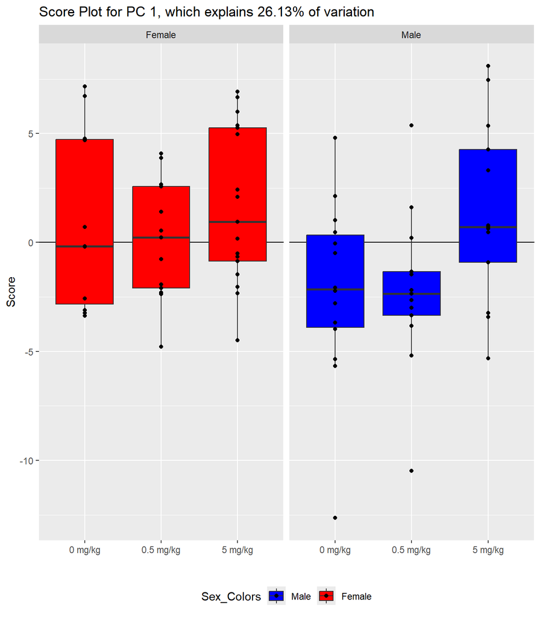

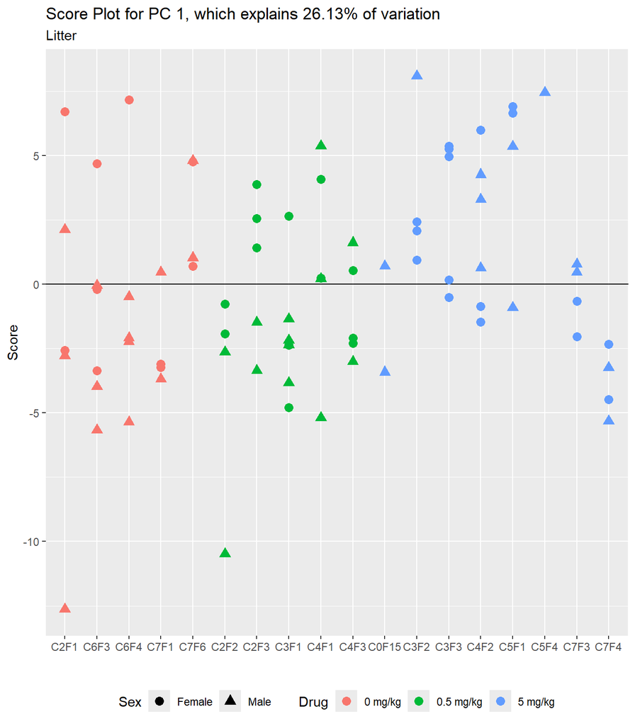

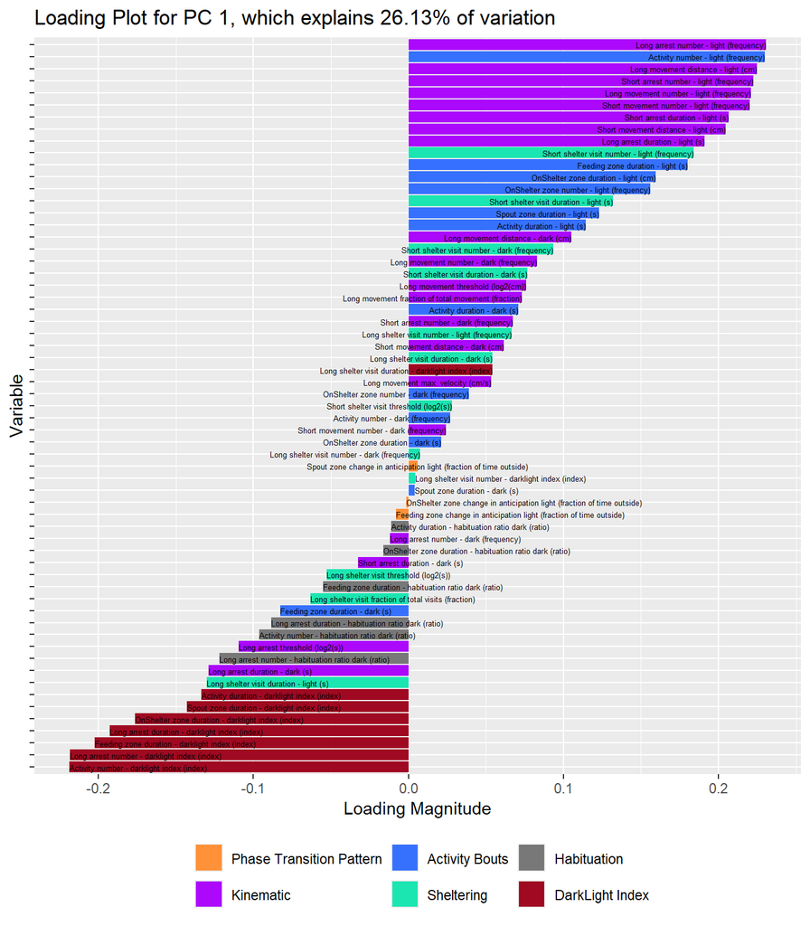

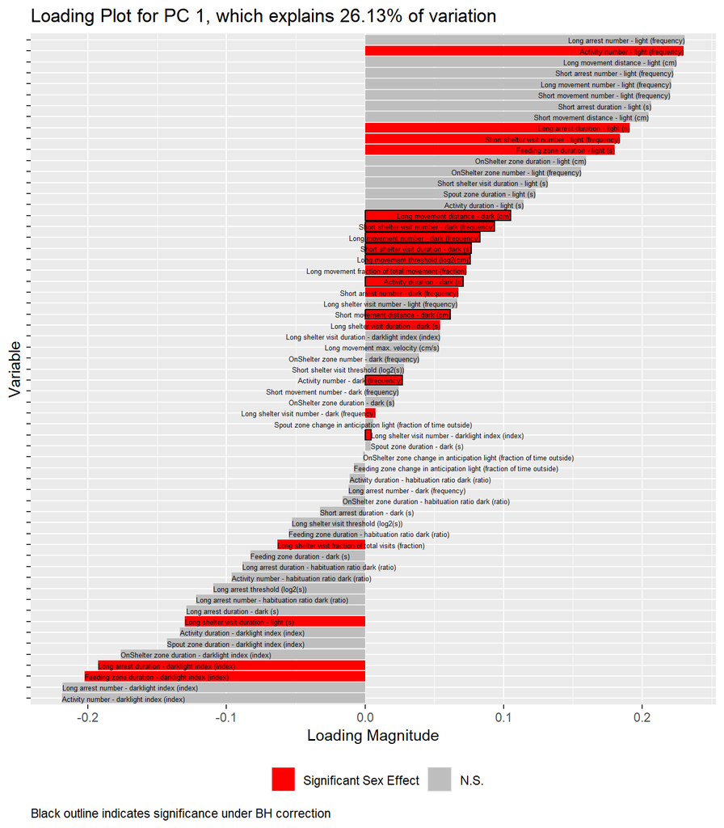

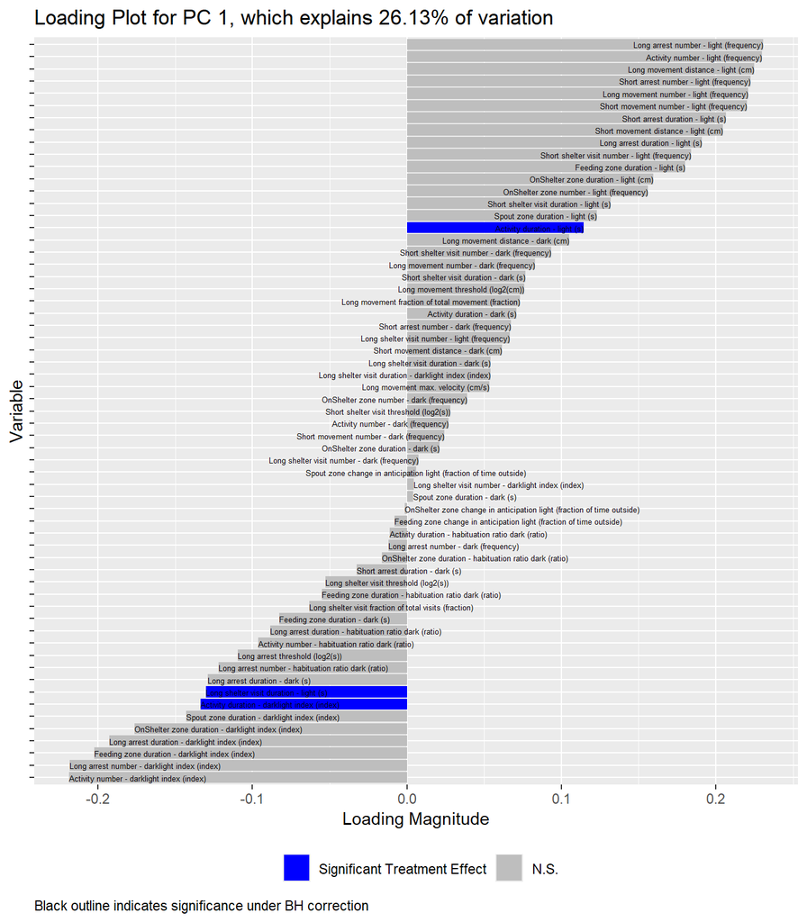

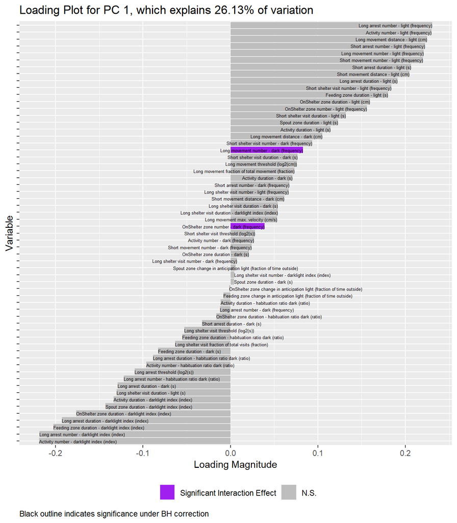

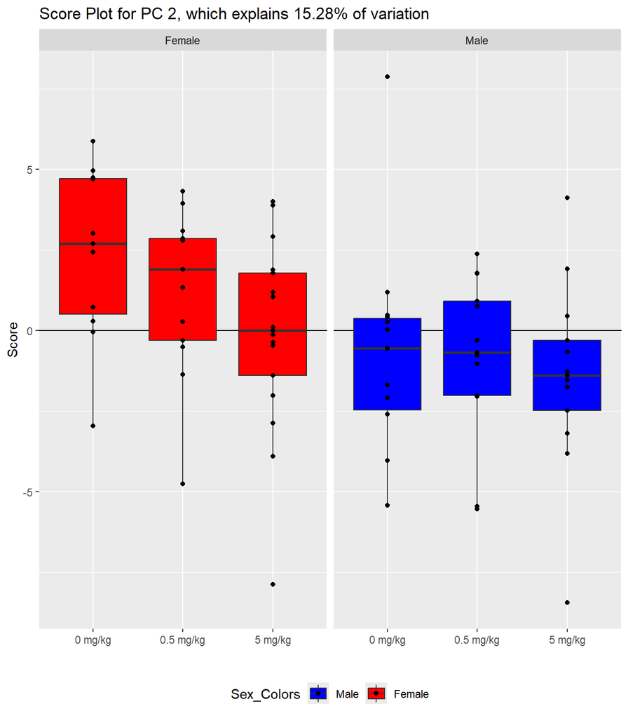

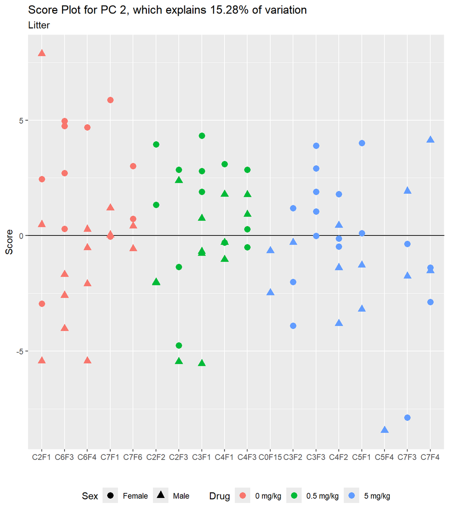

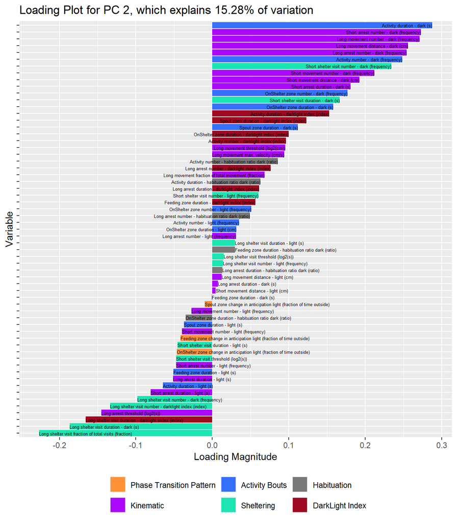

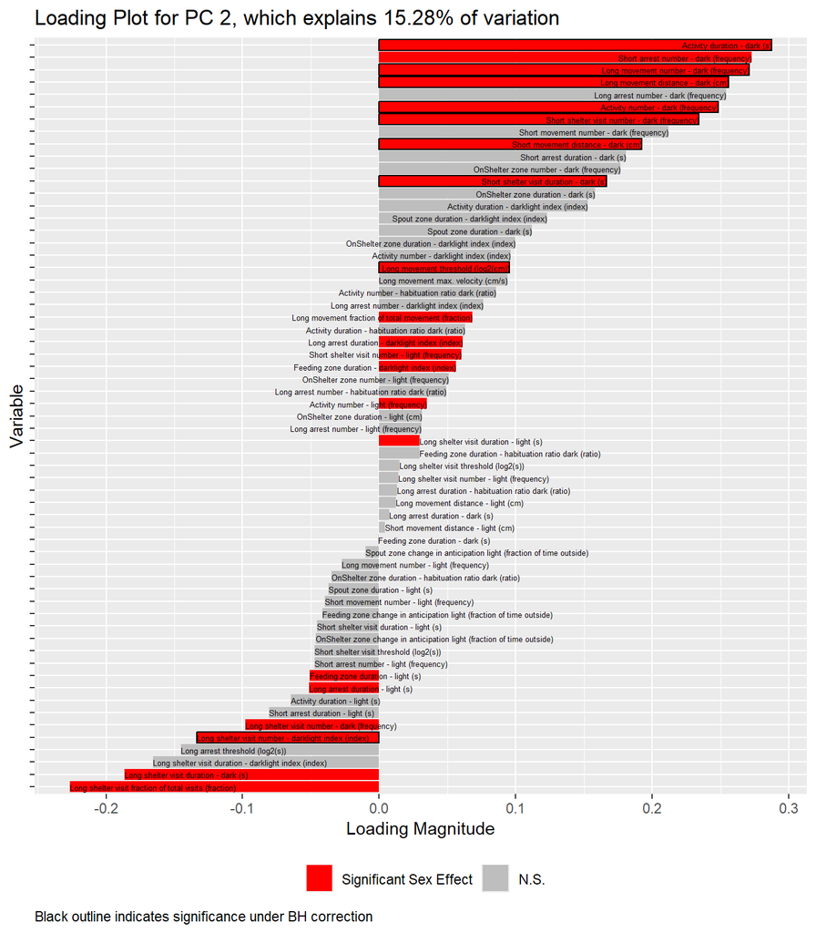

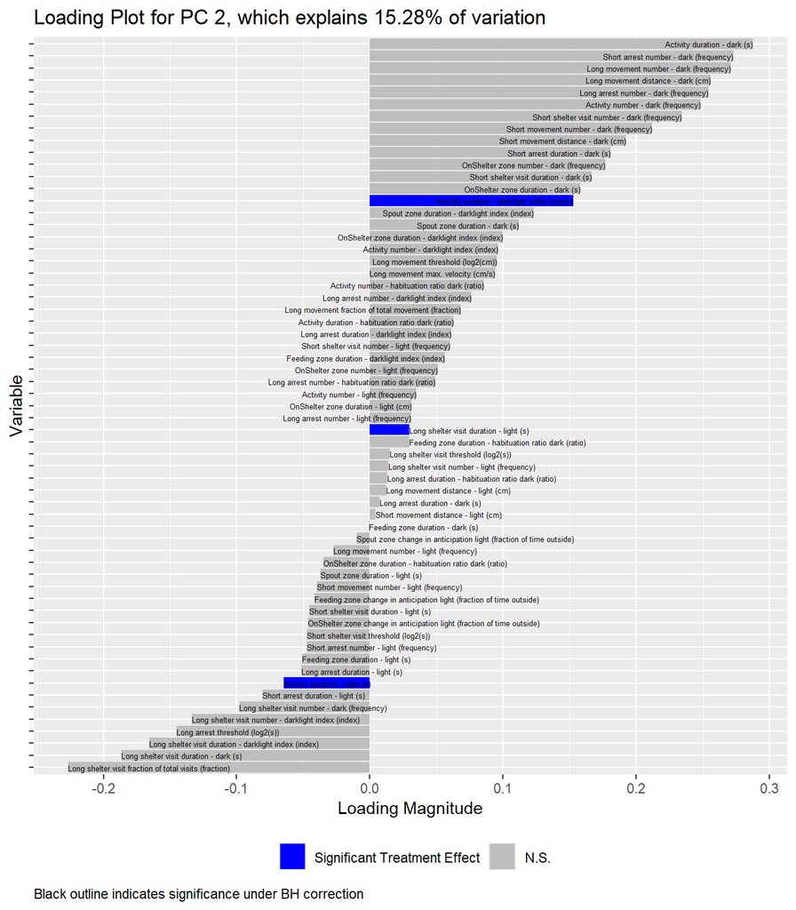

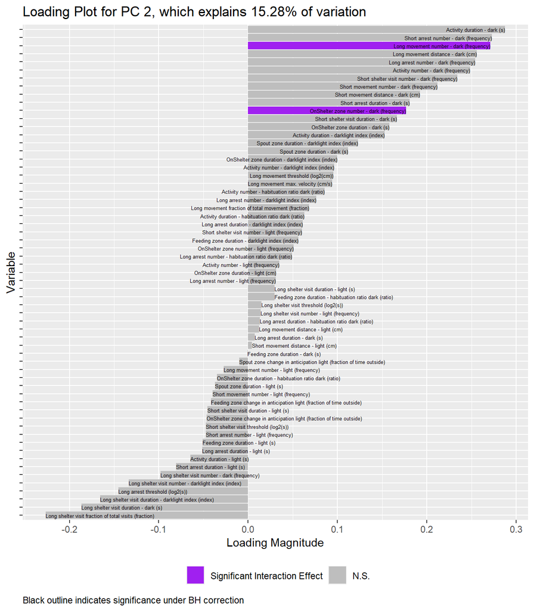

[12 more figures not shown]

## Other PC Plots

Below are plots of first three principal components. The first 3D plot is interactive; it can be clicked, dragged, and reoriented. The lower three plots show each of the first three PCs against the others.

[interactive chart not shown]

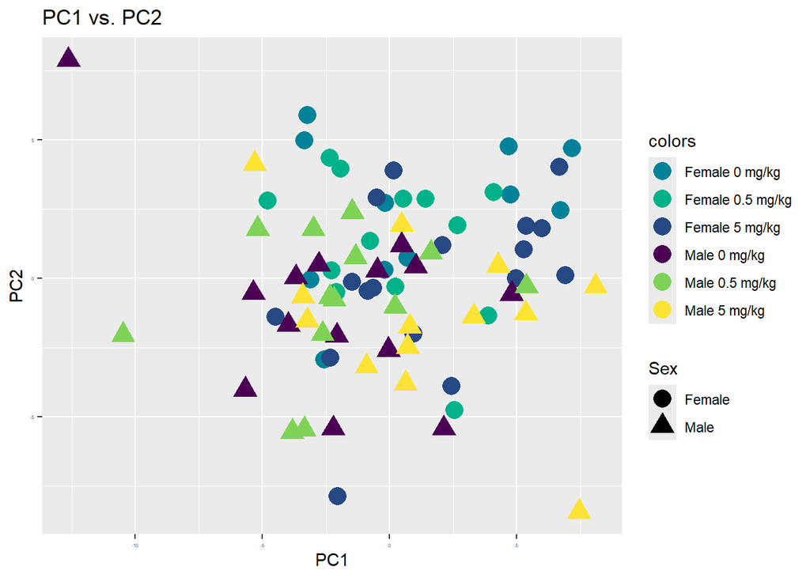

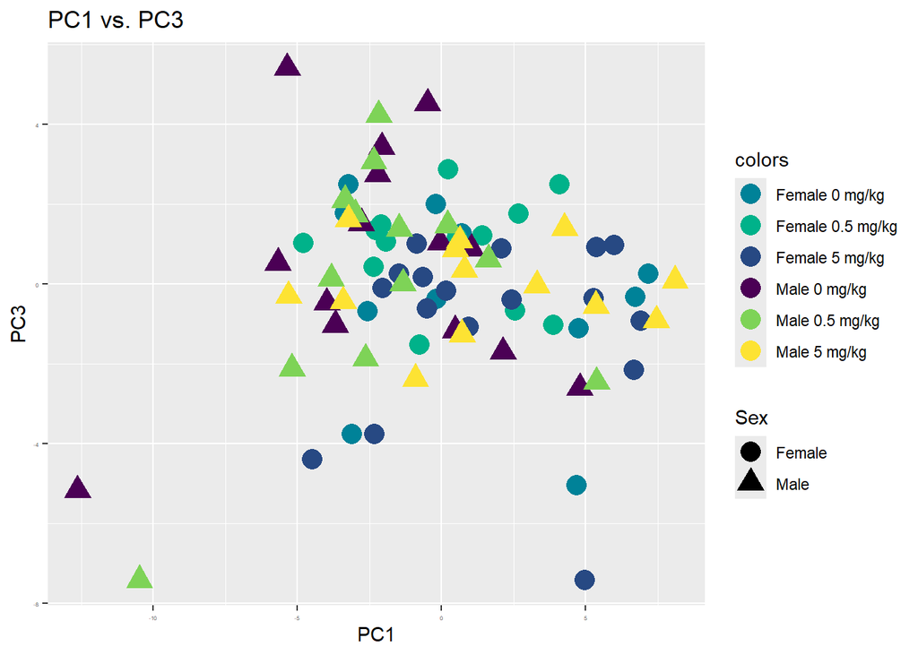

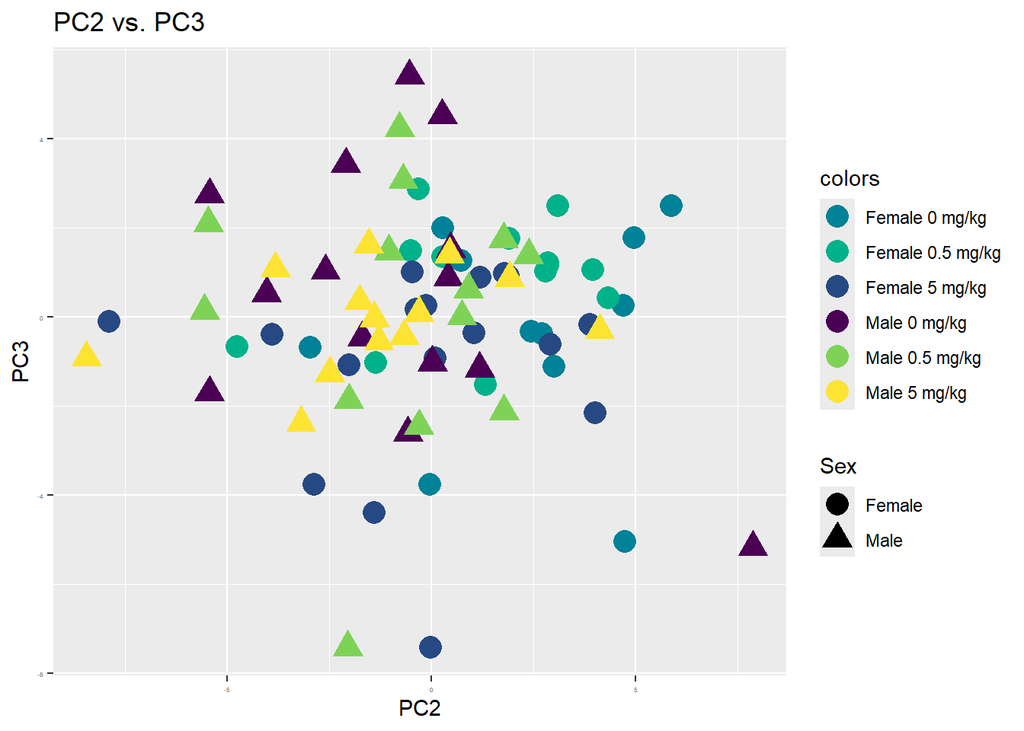

## Extra Statistical Details

For completeness, there are a few extra outputs that are useful for statistical QC, particularly when there are litter effects present in the data.

### % Variability explained by litter in raw data

If litter effects are present, the following is a table with the percent of variability explained by the random litter effect in an interaction model with Sex, Treatment, and their interaction. If the percent of variability is less than 1%, then the values are not adjusted for litter.

| Parameter and Unit | % of Variability explained by Litter |
| --- | --- |
| Long shelter visit duration - darklight index (index) | 44.11% |
| OnShelter zone duration - habituation ratio dark (ratio) | 36.62% |
| Long movement distance - light (cm) | 35.86% |
| Long shelter visit number - dark (frequency) | 34.65% |
| Long arrest duration - darklight index (index) | 33.01% |
| Long shelter visit number - darklight index (index) | 29.61% |
| Activity number - light (frequency) | 28.42% |
| Long shelter visit threshold (log2(s)) | 27.85% |
| Short arrest duration - dark (s) | 26.48% |
| Long arrest threshold (log2(s)) | 24.87% |
| Long movement threshold (log2(cm)) | 24.49% |
| Long arrest number - darklight index (index) | 24.33% |
| Long arrest number - light (frequency) | 23.94% |
| Long movement number - light (frequency) | 23.23% |
| Activity number - darklight index (index) | 22.08% |
| Long arrest duration - light (s) | 22.03% |
| Short shelter visit number - dark (frequency) | 21.22% |
| Short movement distance - light (cm) | 20.9% |
| Long movement max. velocity (cm/s) | 20.08% |
| Short arrest number - light (frequency) | 19.45% |
| Short shelter visit number - light (frequency) | 19.39% |
| Feeding zone duration - dark (s) | 18.68% |
| Long shelter visit number - light (frequency) | 18.68% |
| Feeding zone change in anticipation light (fraction of time outside) | 18.19% |
| Short movement number - light (frequency) | 18.07% |
| Feeding zone duration - darklight index (index) | 17.9% |
| OnShelter zone duration - dark (s) | 12.45% |
| OnShelter zone number - dark (frequency) | 12.08% |
| Spout zone change in anticipation light (fraction of time outside) | 12.06% |
| Activity change in response to light (fraction of total time) | 11.55% |
| Long shelter visit duration - dark (s) | 11.08% |
| Short arrest duration - light (s) | 10.79% |
| Short shelter visit duration - light (s) | 10.58% |
| Long shelter visit fraction of total visits (fraction) | 10.26% |
| OnShelter zone duration - light (cm) | 10.22% |
| Activity duration - habituation ratio dark (ratio) | 8.97% |
| OnShelter zone duration - darklight index (index) | 7.61% |
| Short shelter visit threshold (log2(s)) | 6.86% |
| Long movement fraction of total movement (fraction) | 6.72% |
| Long arrest duration - dark (s) | 6.3% |
| Feeding zone duration - light (s) | 6.28% |
| Short movement distance - dark (cm) | 4.02% |
| Activity change in anticipation of light (fraction of total time) | 3.63% |
| Activity number - habituation ratio dark (ratio) | 2.32% |
| Long movement distance - dark (cm) | 1.75% |
| Spout zone duration - habituation ratio dark (ratio) | 1.1% |
| Spout zone duration - darklight index (index) | 1.09% |
| Long arrest number - habituation ratio dark (ratio) | 0.66% |
| Short shelter visit duration - dark (s) | 0.33% |
| Short movement number - dark (frequency) | 0% |
| OnShelter zone number - light (frequency) | 0% |
| Spout zone duration - light (s) | 0% |
| Long shelter visit duration - light (s) | 0% |
| Short arrest number - dark (frequency) | 0% |
| Feeding zone duration - habituation ratio dark (ratio) | 0% |
| Activity duration - dark (s) | 0% |
| Long movement number - dark (frequency) | 0% |
| Activity duration - light (s) | 0% |
| Activity number - dark (frequency) | 0% |
| Long shelter visit duration - habituation ratio dark (ratio) | 0% |
| Spout zone duration - dark (s) | 0% |
| Long arrest number - dark (frequency) | 0% |
| OnShelter zone change in anticipation light (fraction of time outside) | 0% |
| Long arrest duration - habituation ratio dark (ratio) | 0% |
| Activity duration - darklight index (index) | 0% |

### Percent of Variability explained by litter in ANOVA models on PCs

These ANOVAs, run on the principal components, were done after the adjustments. We do not expect there to be big litter effects present. Models are nested ANOVAs (interaction first, if not significant, then additive).

| PC | % Variation Explained by PC | ANOVA p-values Sex | ANOVA p-values Treatment | ANOVA p-values Sex x Treatment | % Variation Explained by Litter |  |
| --- | --- | --- | --- | --- | --- | --- |
| PC1 | 26.13 | 0.02 | 0.16 | NA |  | 19.24% |
| PC2 | 15.28 | 0.00 | 0.16 | NA | 0% |  |
| PC3 | 8.66 | 0.63 | 0.46 | NA | 21.01% |  |
| PC4 | 6.06 | 0.19 | 0.50 | NA | 7.63% |  |
| PC5 | 5.41 | 0.22 | 0.88 | NA | 33.58% |  |
| PC6 | 4.73 | 0.86 | 0.43 | NA | 4.38% |  |
| PC7 | 3.82 | 0.29 | 0.32 | 0.04 | 12.79% |  |
| PC8 | 3.40 | 0.76 | 0.96 | NA | 13.74% |  |
| PC9 | 2.75 | 0.89 | 0.56 | NA | 0% |  |
| PC10 | 2.62 | 0.88 | 0.46 | NA | 3.23% |  |
| PC11 | 2.31 | 0.90 | 0.80 | NA | 0% |  |
| PC12 | 2.17 | 0.26 | 0.80 | NA | 24.8% |  |
| PC13 | 1.74 | 0.02 | 0.62 | NA | 24.78% |  |
| PC14 | 1.67 | 0.54 | 0.29 | NA | 2.98% |  |
| PC15 | 1.44 | 0.08 | 0.65 | NA | 7.71% |  |
| PC16 | 1.21 | 0.34 | 0.61 | NA | 0% |  |
| PC17 | 1.11 | 0.50 | 0.71 | 0.00 | 0% |  |
| PC18 | 0.96 | 0.62 | 0.58 | NA | 5.05% |  |
| PC19 | 0.86 | 0.37 | 0.90 | NA | 6.5% |  |
| PC20 | 0.83 | 0.02 | 0.06 | NA | 0% |  |
| PC21 | 0.78 | 0.94 | 0.13 | NA | 3.73% |  |
| PC22 | 0.64 | 0.67 | 0.46 | NA | 0% |  |
| PC23 | 0.60 | 0.87 | 0.95 | NA | 15.78% |  |
| PC24 | 0.50 | 0.31 | 0.77 | NA | 6.32% |  |
| PC25 | 0.49 | 0.05 | 0.35 | NA | 10.26% |  |
| PC26 | 0.44 | 0.93 | 0.18 | NA | 4.68% |  |
| PC27 | 0.37 | 0.03 | 0.53 | NA | 0% |  |
| PC28 | 0.35 | 0.92 | 0.13 | NA | 0% |  |
| PC29 | 0.29 | 0.44 | 0.54 | NA | 8.8% |  |
| PC30 | 0.26 | 0.62 | 0.73 | NA | 9.53% |  |
| PC31 | 0.24 | 0.02 | 0.44 | NA | 0% |  |
| PC32 | 0.22 | 0.66 | 0.76 | NA | 0% |  |
| PC33 | 0.20 | 0.58 | 0.05 | NA | 3.47% |  |
| PC34 | 0.20 | 0.08 | 0.47 | NA | 0% |  |
| PC35 | 0.16 | 0.52 | 0.21 | NA | 0% |  |
| PC36 | 0.15 | 0.18 | 0.50 | NA | 0% |  |
| PC37 | 0.13 | 0.07 | 0.85 | NA | 0% |  |
| PC38 | 0.11 | 0.43 | 0.20 | NA | 2.19% |  |
| PC39 | 0.10 | 0.75 | 0.54 | NA | 0% |  |
| PC40 | 0.09 | 0.69 | 0.24 | NA | 0% |  |
| PC41 | 0.08 | 0.23 | 0.42 | NA | 0% |  |
| PC42 | 0.06 | 0.77 | 0.64 | NA | 0% |  |
| PC43 | 0.06 | 0.31 | 0.69 | NA | 0% |  |
| PC44 | 0.06 | 0.44 | 0.74 | NA | 0% |  |
| PC45 | 0.05 | 0.62 | 0.50 | NA | 2.77% |  |
| PC46 | 0.04 | 0.32 | 0.57 | NA | 3.55% |  |
| PC47 | 0.03 | 0.76 | 0.69 | NA | 0% |  |
| PC48 | 0.03 | 0.96 | 0.87 | NA | 0% |  |

# Output results

While many of the results have been presented in graphical or tabular form here, it may be useful to see them in table form. You can find them in ../Results for Practice/PhenotyperPCA Project_PCASuite_2026-11-27.xlsx.